# Homework02 - Group B

Matilde Castelli -Eros Fabrici - Sebastiano Zagatti

# LAB

## Exercise 1

**Check the biased nature of $s^2_b$ via MC simulation, generating $n=10$ iid values from a normal distribution. Plot also $s^2$ and comment the difference.**

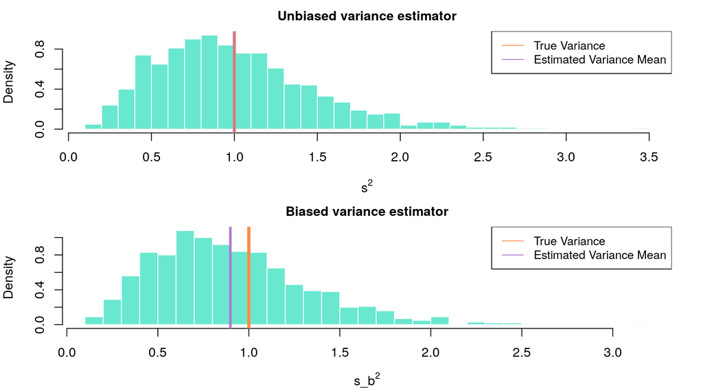

```r
set.seed(123)
R <-1000
n <- 10
#function for the biased variance estimator
var_biased<-function(n){
  return (var(n)*(length(n)-1)/length(n))
}

#retun an array (n x R = 10 x 1000)
samples <- (replicate(R,rnorm(n,0,1)))

samples_stat<- array(0,c(2,R))
#samples_stat[1,]<-apply(samples,2,mean)

#unbiased variance
samples_stat[1,]<-apply(samples,2, var)
#biased estimator
samples_stat[2,]<- apply(samples,2,var_biased)

sigma<-1

par (mfrow=c(2,1),mar=c(4,4,2,2), oma=c(0,0,0,0))
#-----------------plot unbiased estimator
hist(samples_stat[1, ], breaks= 40, probability = TRUE,
     xlab=expression(s^2), main= "Unbiased variance estimator",
     cex.main=1.0, col="#6AE7CF", border="white")
#curve(((n-1)/sigma^2) * dchisq(x * ((n-1)/sigma^2), df = n - 1), add = TRUE, col="#368D91", lwd=2, main="N(0,1)")
abline(v = sigma, col = "#FF8C45", lwd = 4)
abline(v = mean(samples_stat[1,]), col = "#AF78CB", lwd = 2)
legend("topright",c("True Variance","Estimated Variance Mean"),cex=.9,col=c("#FF8C45","#AF78CB"),lty=1:1)

#-------------------------------------------- plot biased estimator
hist(samples_stat[2, ], breaks= 40, probability = TRUE,
     xlab=bquote(s_b^2), main= "Biased variance estimator",
     cex.main=1.0,col="#6AE7CF",border="white")
abline(v = sigma, col = "#FF8C45", lwd = 4)
abline(v = mean(samples_stat[2,]), col = "#AF78CB", lwd = 3)
legend("topright", c("True Variance","Estimated Variance Mean"),
       cex=.9,col=c("#FF8C45","#AF78CB"),lty=1:1)
```

In the first plot we can see the unbiasedness visually, using a density plot of estimated variances with a line for the true variance. We can notice that the variance $s^2$ is an unbiased estimator for the population variance: the expected value or the mean of $s^2$ is very close to the true value of the variance $\sigma^2$. On the contrary in the second plot we can see that $s_b^2$ is a bias estimator for the population variance: the expected value or the mean of $s_b^2$ is smaller than the true variance. ($E[s_b^2]$=0.8985435 < $\sigma^2$ = 1). Indeed $E[s_b^2] = \frac{n-1}{n} \sigma^2$, and the bias is $bias(s_b^2)=E[s_b^2]- \sigma^2 = -\sigma^2/n$.

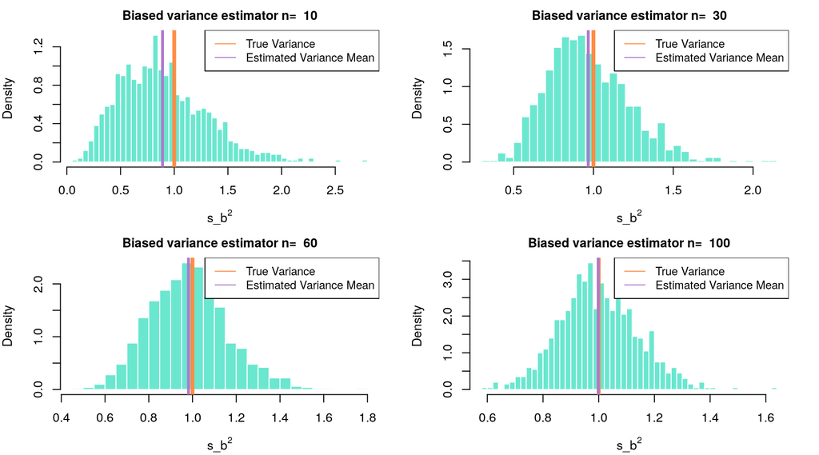

```r
set.seed(123)
R <-1000
n <- 10
sigma<-1

var_biased <- function(n){
  return (var(n)*(length(n)-1)/length(n))
}
sampvals <- function(n)(rnorm(n,0,1))
samplingDist <- function(sampsize=10, nsamp=1000, FUN=var_biased)
apply(matrix(sampvals(sampsize*nsamp), ncol=sampsize), 1, FUN)

size <- c(10,30,60,100)

df <- data.frame(y1=samplingDist(sampsize=size[1]),
y2=samplingDist(sampsize=size[2]),
y3=samplingDist(sampsize=size[3]),
y4=samplingDist(sampsize=size[4]))


bias<-colMeans(df)-sigma
par (mfrow=c(2,2),mar=c(4,4,2,2), oma=c(0,0,0,0))
for(i in 1:4){

hist(df[,i], breaks= 40, probability = TRUE,
xlab=bquote(s_b^2), main= paste("Biased variance estimator n= ", size[i]), cex.main=1.0,col="#6AE7CF",border="white")
abline(v = sigma, col = "#FF8C45", lwd = 4)
abline(v = mean(df[,i]), col = "#AF78CB", lwd = 3)
legend("topright",c("True Variance","Estimated Variance Mean"),cex=.9,col=c("#FF8C45","#AF78CB"),lty=1:1)
}
```

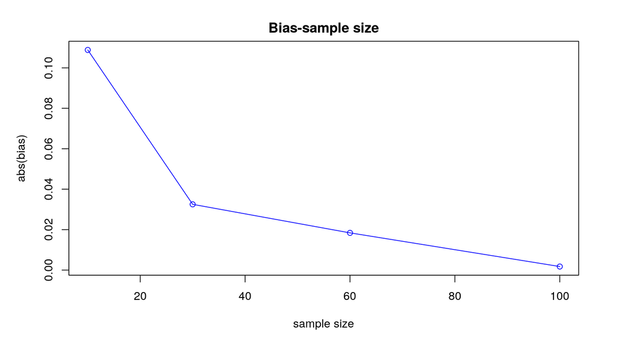

```r
par (mfrow=c(1,1),mar=c(4,4,2,2), oma=c(1,1,1,1))
plot(size,abs(bias), main = "Bias-sample size", type="o", col="blue",xlab="sample size")
```

For large sample size we can see that we can also rely on the biased estimator $s_b^2$. As the sample size increases the mean of $s_b^2$ get closer and closer to the true population variance and to the value of the unbiased estimator $s^2$, since the difference between $n$ and $n-1$ becomes negligible.

## Exercise 2

**What happens if a great player decides to join you, now? Try to simulate the data and perform the test again.**

```r
set.seed(101)

#num of observations
n <- 50
#num of categories
K <- 4
#number of "players"
m <- 6

nullHypo <- c(7/16, 5/16, 3/16, 1/16)

observed <- matrix(0, nrow = m, ncol = n)
for (i in 1:m) {
  observed[i,] <- sample(1:K, n, prob = nullHypo, replace = TRUE)
}

#p-value very high (0.8074)
print( chisq.test( table(observed), p = nullHypo ) )
```

```
##
##  Chi-squared test for given probabilities
##
## data:  table(observed)
## X-squared = 0.97473, df = 3, p-value = 0.8074
```

```r
# New player with better skills join
observed <- rbind(observed,
                  sample(1:K, n, prob = c(1/16, 3/16, 5/16, 7/16), replace = TRUE)
                 )

#now the p-value is incredibly low
print(chisq.test( table(observed), p = nullHypo)  )
```

```
##
##  Chi-squared test for given probabilities
##
## data:  table(observed)
## X-squared = 29.343, df = 3, p-value = 1.897e-06
```

The p-value of the first test is very high thus, if we would set the significance level to 5%, we would not reject $H_0$, while, in the second case, after adding the observations of the good player sampled with a different probability vector (i.e. 1/16, 3/16, 5/16, 7/16) the p-value is lesser than 0.01, indicating a strong evidence against $H_0$.

## Exercise 3

**Sometimes it could be useful to assess the degree of association, or correlation, between paired samples, using the Pearson, the Kendall’s $\tau$ or the Spearman’s $\rho$ correlation coefficient. Regardless of the adopted cofficient, the null hypothesis for a given correlation coefficent $\rho$ is:**
$$H_0:\rho=0.$$
**The test statistic is then defined as**
$$T = r\sqrt{\frac{n-2}{1-r^2}} \underset{H_0}{\sim} t_{n-2}$$

**where $r=Corr(X,Y)$ is the Pearson correlation coefficient. Suppose to have two samples of the same length $x1,…,xn,y1,…,yn$, and to measure the association between them. Once we compute the test statistic $t_{obs}$, we may then compute the $p$-value (here we are evaluating a two sided test) as:**
$$p = 2Pr_{H_0}(T \geq |t_{obs}|)$$
**Consider now some of the most followed Instagram accounts in 2018: for each of the owners, we report also the number of Twitter followers (in milions). Are the Instagram and Twitter account somehow associated? Perform a correlation test, compute the p-value and give an answer. Here is the dataframe.**

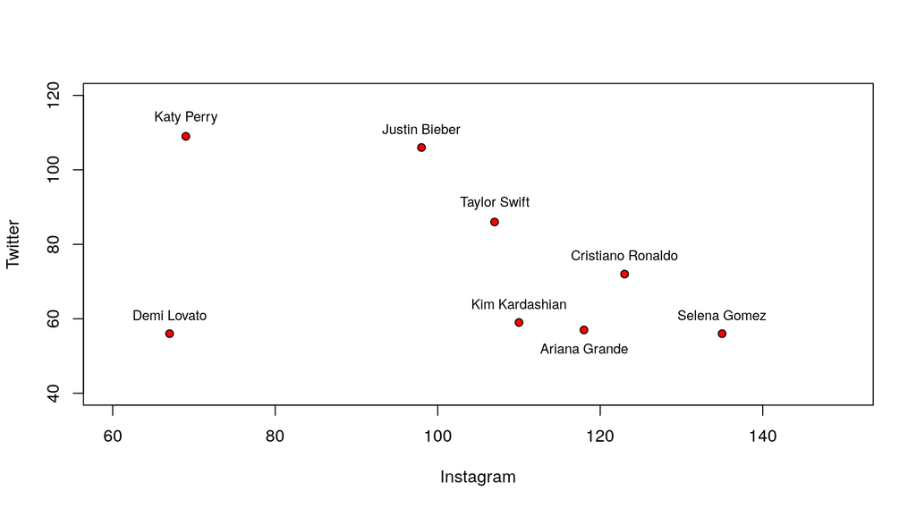

```r
Owners <- c( "Katy Perry", "Justin Bieber", "Taylor Swift", "Cristiano Ronaldo",
             "Kim Kardashian", "Ariana Grande", "Selena Gomez", "Demi Lovato")
Instagram <- c( 69, 98,107, 123, 110, 118, 135, 67)
Twitter <- c( 109, 106, 86, 72, 59, 57, 56, 56)
plot( Instagram, Twitter, pch=21, bg=2, xlim=c(60, 150), ylim=c(40, 120) )
text( Instagram[-6], Twitter[-6]+5, Owners[-6], cex=0.8 )
text( Instagram[6], Twitter[6]-5, Owners[6], cex=0.8 )
```

```r
#**Manual Computation of the p-value:**

n <- length(Instagram)
#compute Pearson's correlation coefficient
r <- ((n*sum(Instagram*Twitter))-(sum(Instagram)*sum(Twitter)))/((sqrt((n*sum(Instagram^2))-(sum(Instagram))^2))*(sqrt((n*sum(Twitter^2))-(sum(Twitter))^2)))
#compute the test statistic
x <- r*sqrt((n-2)/(1-r^2))
#compute the p-value
a <- pt(x, df =n-2, lower.tail =FALSE )
p <- 2*(1-a)
p
```

```
## [1] 0.2956669
```

```r
#**Correlation test (Pearson) using the built in R function**
t <- cor.test(Instagram, Twitter,
         alternative = "two.sided",
         method = "pearson", conf.level = 0.95)
t
```

```
##
##  Pearson's product-moment correlation
##
## data:  Instagram and Twitter
## t = -1.1454, df = 6, p-value = 0.2957
## alternative hypothesis: true correlation is not equal to 0
## 95 percent confidence interval:
##  -0.8689006  0.4006898
## sample estimates:
##        cor
## -0.4235845
```

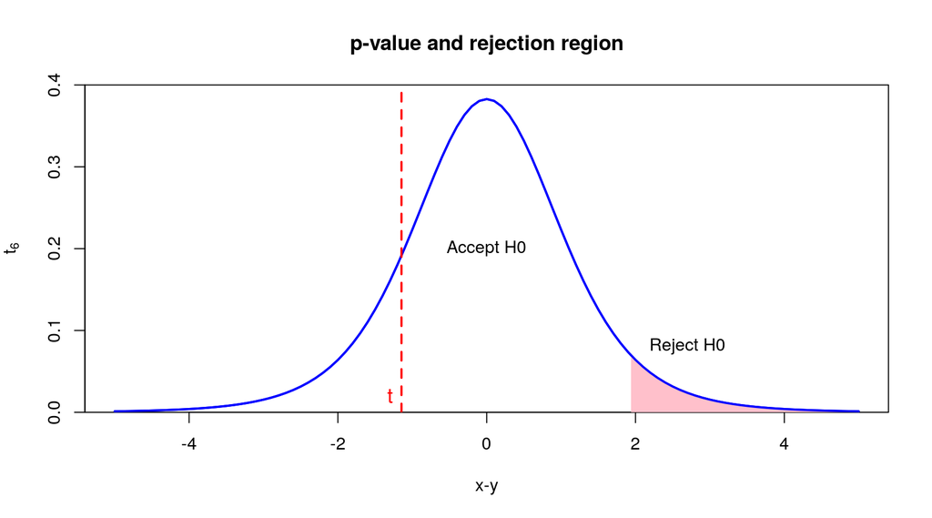

```r
#**Display acceptance and rejection regions**
curve(dt(x,6),xlim=c(-5,5), ylim=c(0,0.4),
      main="p-value and rejection region", col = "blue", lwd = 2, xlab="x-y",  ylab=expression(t[6]),  yaxs="i")
cord.x <- c(qt(0.95,6),seq(qt(0.95,6), 5, 0.01), 5)
cord.y <- c(0,dt(seq(qt(0.95,6), 5, 0.01),6),0)
polygon(cord.x,cord.y,col="pink", border = NA )
curve(dt(x,6),xlim=c(-5,5),main=expression(t[6]), col = "blue", lwd = 2, add = TRUE, yaxs="i")
abline(v =t$statistic, lty=2, lwd=2, col="red")
text (0,0.2, paste("Accept", expression(H0)))
text (2.7,0.08, paste("Reject", expression(H0)))
text(as.double(t$statistic)-0.15, 0.02, "t", col="red", cex=1.2)
```

The p-value has been computed both manually and using the built-in $\mathsf{R}$ function. As displayed in the code, the p-value is almost 6 times greater than the significance level $\alpha=0.05$, so the null hypothesis $H_0: \rho = 0$ is not rejected, meaning that there is no correlation between the two datasets.

## Exercise 4

**Compute analitically $J(γ,γ;y),J(γ,β;y),J(β,β;y)$.**

Firstly we consider a sample of iid values y from a Weibull distribution, $Y\sim We(\gamma,\beta)$ with parameter $\theta = (\gamma, \beta)$ and density function:
$$f(y; \gamma,\beta)= \frac{\gamma}{\beta}(\frac{y}{\beta})^{\gamma-1}e^{-(y/\beta)^\gamma} \text{ , y},\gamma,\beta >0$$
We want to compute the **observed information** matrix, given by:
$$J(\theta;y) = -\frac{\partial\ell(\theta;y)}{\partial\theta\partial\theta^T}$$
The log-likelihood is defined as:
$$\ell(\gamma,\beta;y) = n\log\gamma - n\gamma\log\beta + \gamma\sum_{i=1}^n\log(y_i) - \sum_{i=1}^n(\frac{y_i}{\beta})^\gamma$$

The first step is to calculate the first order partial derivatives with respect to $\beta$ and $\gamma$:

$$\begin{aligned}
\frac{\partial}{\partial\beta}\ell(\gamma,\beta;y) &= -\frac{n}{\beta}\gamma + \frac{\gamma}{\beta^{\gamma+1}}\sum_{i=1}^n y_i^\gamma\\
\frac{\partial}{\partial\gamma}\ell(\gamma,\beta;y) &= \frac{n}{\gamma} - n\log\beta + \sum_{i=1}^n\log y_i - \sum_{i=1}^n (\frac{y_i}{\beta})^\gamma\log(\frac{y_i}{\beta})
\end{aligned}$$

Then, we compute the second partial derivatives: $\frac{\partial^2\ell}{\partial\beta^2}, \frac{\partial^2\ell}{\partial\gamma^2}$ and $\frac{\partial^2\ell}{\partial\beta\partial\gamma}$. Due to the Hessian symmetry,$\frac{\partial^2\ell}{\partial\beta\partial\gamma} = \frac{\partial^2\ell}{\partial\gamma\partial\beta}$

$$\begin{aligned}
\frac{\partial^2\ell}{\partial\beta^2} &= \frac{n\gamma}{\beta^2} - \frac{\gamma(\gamma + 1)}{\beta^{\gamma+2}}\sum_{i=1}^ny_i^\gamma \\[10pt]
\frac{\partial^2\ell}{\partial\gamma^2} &= -\frac{n}{\gamma^2} - \sum_{i=1}^n (\frac{y_i}{\beta})^\gamma(\log(\frac{y_i}{\beta}))^2\\[10 pt]
\frac{\partial^2\ell}{\partial\beta\partial\gamma} &= - \frac{n}{\beta} -\sum_{i=1}^n \left[ \frac{(y_i)^\gamma(-\gamma)}{\beta^{\gamma+1}})\log(\frac{y_i}{\beta}) + (\frac{y_i}{\beta})^\gamma(-\frac{1}{\beta})\right] \\[5 pt]
&= - \frac{n}{\beta} + \sum_{i=1}^n \frac{y_i^\gamma}{\beta^{\gamma+1}}(\gamma\log(\frac{y_i}{\beta}) + 1) \\
\end{aligned}$$

The observed information matrix is given by:
$$\begin{equation*}
J(\gamma,\beta;y) = -
\begin{pmatrix}
\frac{\partial^2\ell(\gamma,\beta)}{\partial\gamma^2} & \frac{\partial^2\ell(\gamma,\beta)}{\partial\beta\partial\gamma} \\
\frac{\partial^2\ell(\gamma,\beta)}{\partial\gamma \partial\beta} & \frac{\partial^2\ell(\gamma,\beta)}{\partial\beta^2} \\
\end{pmatrix}
\end{equation*}$$

So in the end we have:
$$\begin{equation*}
J(\gamma,\beta;y) =
\begin{pmatrix}
\frac{n}{\gamma^2} + \sum_{i=1}^n (\frac{y_i}{\beta})^\gamma(\log(\frac{y_i}{\beta}))^2 & \frac{n}{\beta} - \sum_{i=1}^n \frac{y_i^\gamma}{\beta^{\gamma+1}}(\gamma\log(\frac{y_i}{\beta}) + 1) \\
\frac{n}{\beta} - \sum_{i=1}^n \frac{y_i^\gamma}{\beta^{\gamma+1}}(\gamma\log(\frac{y_i}{\beta}) + 1) & -\frac{n\gamma}{\beta^2} + \frac{\gamma(\gamma + 1)}{\beta^{\gamma+2}}\sum_{i=1}^ny_i^\gamma \\
\end{pmatrix}
\end{equation*}$$
For the other 2 matrices the Weibull distributions change as follow:
$$f(y; \gamma,\gamma)= \left( \frac{y}{\gamma}\right)^{\gamma-1}e^{-(y/\gamma)^\gamma} \text{ , y},\gamma >0$$
$$f(y; \beta,\beta)= \left( \frac{y}{\beta}\right)^{\beta-1}e^{-(y/\beta)^\beta} \text{ , y},\beta >0$$
The log-likelihood functions are:
$$\begin{aligned}
\ell(\gamma,\gamma;y)&= (\gamma -1)\sum_{i=1}^{n}log(y/\gamma)-\sum_{i=1}^n(y/\gamma)^\gamma = (\gamma-1)\sum_{i=1}^nlog(y_i)-n(\gamma-1)log(\gamma) - \sum_{i=1}^n(y/\gamma)^\gamma \\[10pt]
\ell(\beta,\beta;y)&= (\beta-1)\sum_{i=1}^nlog(y_i)-n(\beta-1)log(\beta) - \sum_{i=1}^n(y/\beta)^\beta\\[10pt]
\end{aligned}$$
The first order partial derivatives are:

$$\frac{\partial}{\partial\gamma}\ell(\gamma,\gamma;y) = \sum_{i=1}^n log(y_i)-nlog(\gamma)-\frac{n(\gamma-1)}{\gamma}-\sum_{i=1}^n(y_i/\gamma)^\gamma(log(y_i/\gamma)-1)$$
$$\frac{\partial}{\partial\beta}\ell(\beta,\beta;y) = \sum_{i=1}^n log(y_i)-nlog(\beta)-\frac{n(\beta-1)}{\beta}-\sum_{i=1}^n(y_i/\beta)^\beta(log(y_i/\beta)-1)$$
And the Second order partial derivatives:
$$\begin{aligned}
\frac{\partial^2}{\partial\gamma^2}\ell(\gamma,\gamma;y)&=-\frac{n}{\gamma}(\frac{1}{\gamma}+1)-\sum_{i=1}^n(y_i/\gamma)^\gamma\left[\left(log\left(\frac{y_i}{\gamma}\right)-1\right)^2-\frac{1}{\gamma}\right]\\[10pt]
\frac{\partial^2}{\partial\beta^2}\ell(\beta,\beta;y)&=-\frac{n}{\beta}(\frac{1}{\beta}+1)-\sum_{i=1}^n(y_i/\beta)^\beta\left[\left(log\left(\frac{y_i}{\beta}\right)-1\right)^2-\frac{1}{\beta}\right]
\end{aligned}$$
Therefore the other two observed information matrices are:
$$\begin{equation*}
J(\gamma,\gamma;y) = \frac{n}{\gamma}(\frac{1}{\gamma}+1)+\sum_{i=1}^n(y_i/\gamma)^\gamma\left[\left(log\left(\frac{y_i}{\gamma}\right)-1\right)^2-\frac{1}{\gamma}\right]
\begin{pmatrix}
1 & 1 \\
1 & 1 \\
\end{pmatrix}
\end{equation*} \\$$

$$\begin{equation*}
J(\beta,\beta;y) = \frac{n}{\beta}(\frac{1}{\beta}+1)+\sum_{i=1}^n(y_i/\beta)^\beta\left[\left(log\left(\frac{y_i}{\beta}\right)-1\right)^2-\frac{1}{\beta}\right]
\begin{pmatrix}
1 & 1 \\
1 & 1 \\
\end{pmatrix}
\end{equation*}$$

## Exercise 5

**Produce the contour plot for the quadratic approximation of the log-likelihood, based on the Taylor series:**
$$l(\theta) - l(\hat{\theta}) \approx -\frac{1}{2}(\theta - \hat\theta)^TJ(\hat\theta)(\theta-\hat\theta)$$

```r
library(dplyr) # %>% operator
```

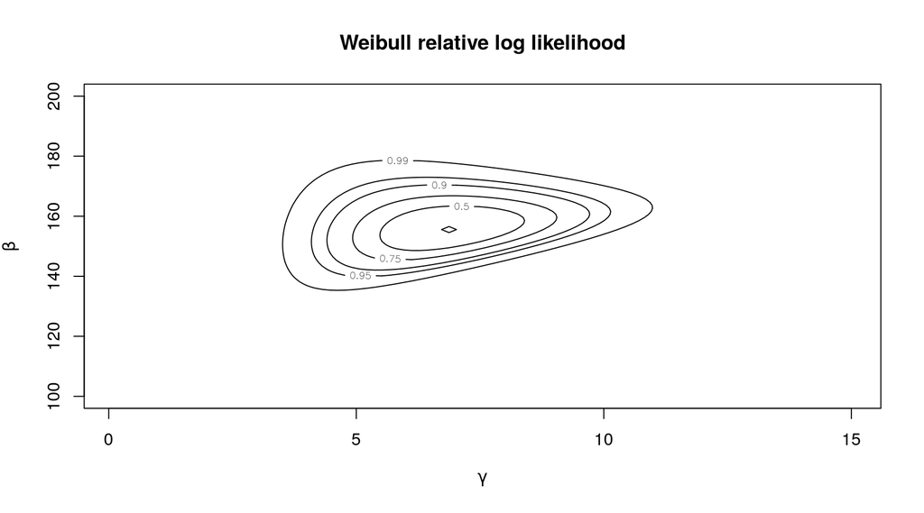

```r
y <- c(155.9, 200.2, 143.8, 150.1,152.1, 142.2, 147, 146, 146,
 170.3, 148, 140, 118, 144, 97)
n <- length(y)
log_lik_weibull <- function(data, param){
  -sum(dweibull(data, shape = param[1], scale = param[2], log = TRUE))
}
 #define parameters grid
gamma <- seq(0.1, 15, length=100)
beta <- seq(100,200, length=100)
parvalues <- expand.grid(gamma,beta)
llikvalues <- apply(parvalues, 1, log_lik_weibull, data=y)
llikvalues <- matrix(-llikvalues, nrow=length(gamma),
                      ncol=length(beta), byrow=F)
conf.levels <- c(0,0.5,0.75,0.9,0.95,0.99)

#contour plot
contour(gamma, beta, llikvalues-max(llikvalues),
        levels=-qchisq(conf.levels, 2)/2,
        xlab=expression(gamma),
        labels=as.character(conf.levels),
        ylab=expression(beta))
title('Weibull relative log likelihood')
```

```r
gammahat <- uniroot(
  function(x) n/x+sum(log(y))-n*sum(y^x*log(y))/sum(y^x),
  c(1e-5,15))$root

betahat<- mean(y^gammahat)^(1/gammahat)
weib.y.mle<-c(gammahat,betahat)
#first element is the MLE for the shape gamma, second element the MLE for the scale beta
print(weib.y.mle)
```

```
## [1]   6.886215 155.948671
```

```r
#observed information matrix
jhat <- matrix(NA,nrow=2,ncol=2)
jhat[1,1] <- n/gammahat^2+sum((y/betahat)^gammahat*(log(y/betahat))^2)
jhat[1,2] <-
jhat[2,1] <-
 n/betahat-sum(y^gammahat/betahat^(gammahat+1)*(gammahat*log(y/betahat)+1))
jhat[2,2]<- -n*gammahat/betahat^2+gammahat*(gammahat+1)/
             betahat^(gammahat+2)*sum(y^gammahat)
infoMatrix <- solve(jhat)
mle.se <- infoMatrix %>% diag %>% sqrt
print(mle.se)
```

```
## [1] 1.242276 6.197266
```

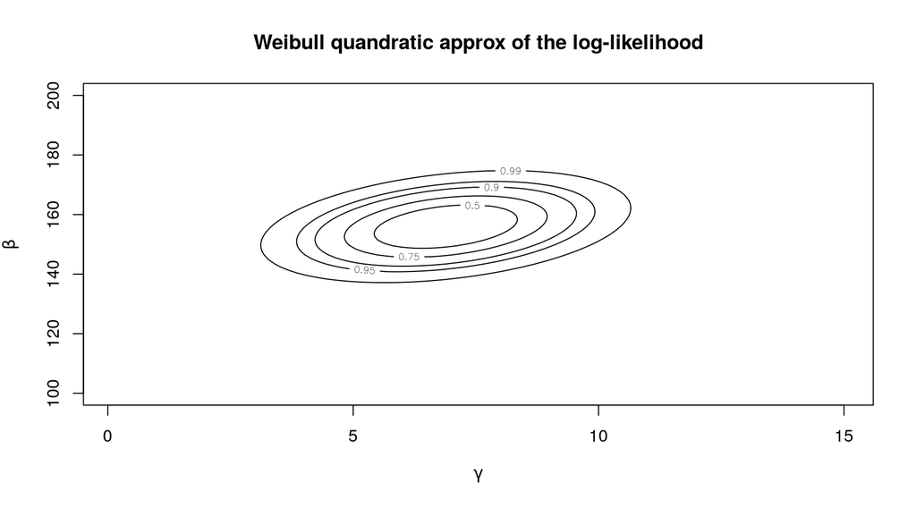

```r
# Computing and plotting the quadratic approximation of the
# log.likelihood
# param variable is theta
quadraticApprox <- function(data, gammaHat, betaHat, param){
    n <- length(data)
    jhat <- matrix(NA, nrow=2, ncol=2)
    jhat[1,1] <-
      n/gammaHat^2+sum((data/betaHat)^gammaHat*(log(data/betaHat))^2)
    jhat[1,2] <-
    jhat[2,1] <-
       n/betahat-sum(data^gammaHat/betaHat^(gammaHat+1)*
                     (gammaHat*log(data/betaHat)+1))
    jhat[2,2] <-
      -n*gammaHat/betaHat^2+gammaHat*(gammaHat+1)/
      betaHat^(gammaHat+2)*sum(data^gammaHat)

    diffThetaThetaHat <- param - c(gammaHat, betaHat)
    res <-
      -1/2 * crossprod(diffThetaThetaHat, jhat) %>%
      tcrossprod(., diffThetaThetaHat)

    return( res )
}

gammaHat <- weib.y.mle[1]
betaHat <- weib.y.mle[2]

quadratricApproxValues <-
  apply(parvalues, 1, quadraticApprox,
        data = y, gammaHat = gammaHat, betaHat = betaHat) %>%
  matrix(., nrow = length(gamma), ncol = length(beta))

contour(gamma, beta, quadratricApproxValues,
        levels=-qchisq(conf.levels, 2)/2,
        xlab=expression(gamma),
        labels=as.character(conf.levels),
        ylab=expression(beta))
title("Weibull quandratic approx of the log-likelihood")
```

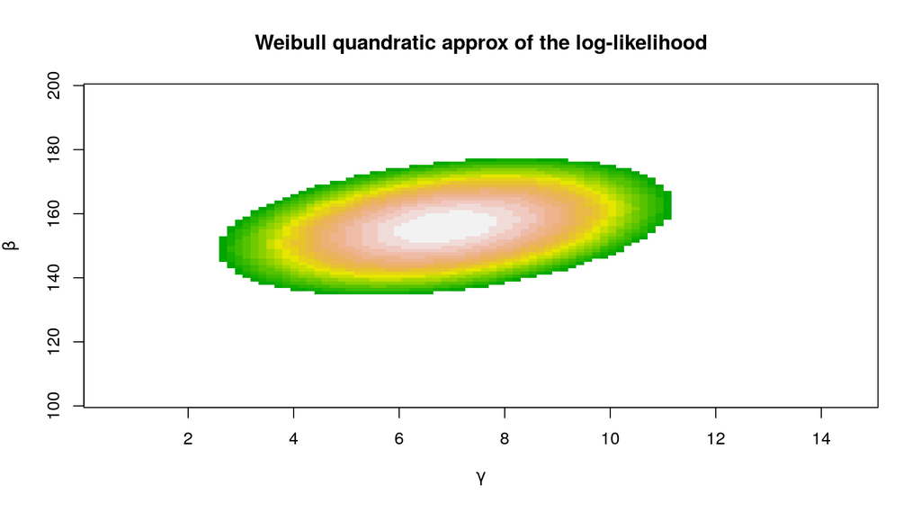

```r
image(gamma, beta, quadratricApproxValues, zlim=c(-6, 0),
      col=terrain.colors(20),xlab=expression(gamma),
      ylab=expression(beta))
title("Weibull quandratic approx of the log-likelihood")
```

# DAAG

## Exercise 11 cap 3

**The following data represent the total number of aberrant crypt foci (abnormal growths in the colon) observed in seven rats that had been administered a single dose of the carcinogen azoxymethane and sacrificed after six weeks (thanks to Ranjana Bird, Faculty of Human Ecology, University of Manitoba for the use of these data):**
$$87 \; 53 \; 72 \; 90 \; 78 \; 85 \; 83$$
**Enter these data and compute their sample mean and variance. Is the Poisson model appropriate for these data? To investigate how the sample variance and sample mean differ under the Poisson assumption, repeat the following simulation experiment several times:**

```r
data <- c(87, 53, 72, 90, 78, 85, 83)
c(mean=mean(data), variance=var(data))
```

```
##      mean  variance
##  78.28571 159.90476
```

```r
#n = 7, lambda=78.3
R<-1000
n<-7
lambda<-78.3
x <- replicate(R, rpois(n, lambda))

samples_stat<- array(0,c(2,R))
samples_stat[1,]<-apply(x,2, mean)
samples_stat[2,]<-apply(x,2, var)

c(mean = mean(samples_stat[1,]),variance=mean(samples_stat[2,]))
```

```
##     mean variance
## 78.23757 79.41486
```

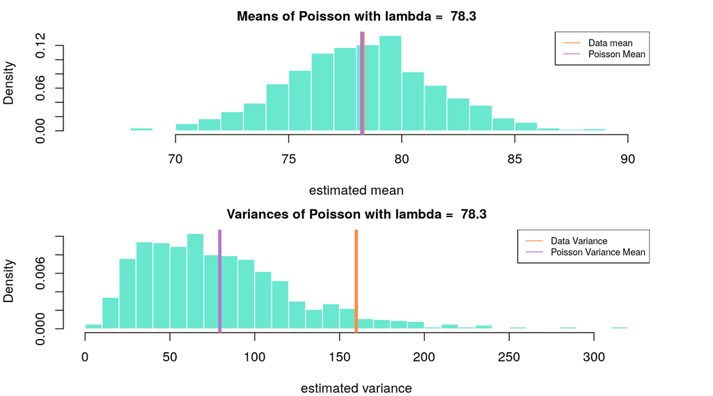

```r
par (mfrow=c(2,1), mar=c(4,4,2,4), oma=c(0,0,0,0))
#plot(min(samples_stat[1, ]): max(samples_stat[1, ]),samples_stat[1, ], type = "h" )
hist(samples_stat[1, ], breaks= 30, probability = TRUE,
xlab="estimated mean", main= paste("Means of Poisson with lambda = ",lambda), cex.main=1.0, col="#6AE7CF",border="white")
abline(v = mean(data), col = "#FF8C45", lwd = 4)
abline(v = mean(samples_stat[1,]), col = "#AF78CB", lwd = 4)
legend("topright",c("Data mean","Poisson Mean"),cex=.7,col=c("#FF8C45","#AF78CB"),lty=1:1)

hist(samples_stat[2, ], breaks= 30, probability = TRUE,
xlab="estimated variance", main= paste("Variances of Poisson with lambda = ",lambda), cex.main=1.0,col="#6AE7CF",border="white")
abline(v = var(data), col = "#FF8C45", lwd = 4)
abline(v = mean(samples_stat[2,]), col = "#AF78CB", lwd = 4)
legend("topright",c("Data Variance","Poisson Variance Mean"),cex=.7,col=c("#FF8C45","#AF78CB"),lty=1:1)
```

We can notice that the mean of the Poisson variance is far away from the variance of the data, making it doubtful that these data are from Poisson distribution.

## Exercise 13 cap 3

**A Markov chain for the weather in a particular season of the year has the transition matrix, from one day to the next:**
$$Pb =
\begin{bmatrix}
& Sun & Cloud & Rain\\
Sun & 0.6 & 0.2 & 0.2\\
Cloud & 0.2 & 0.4 & 0.4\\
Rain & 0.4 & 0.3 & 0.3
\end{bmatrix}$$

**It can be shown, using linear algebra, that in the long run this Markov chain will visit the states according to the *stationary* distribution (data corrected according to https://maths-people.anu.edu.au/~johnm/r-book/3edn/updates/updates2011.pdf):**
$$\begin{matrix}
Sun & Cloud & Rain\\
0.429 & 0.286 & 0.286
\end{matrix}$$

**A result called the *ergodic* theorem allows us to estimate this distribution by simulating the Markov chain for a long enough time.**

**a. Simulate 1000 values, and calculate the proportion of times the chain visits each of the states. Compare the proportions given by the simulation with the above theoretical proportions.**

```r
library(dplyr)
library(zoo)
```

```r
library(lattice)
Markov <- function (N=100, initial.value=1, P) {
  X <- numeric(N)
  X[1] <- initial.value # States {0: 'Sunny', 1: 'Cloudy', 2: 'Rainy'};
  n <- nrow(P)
  for (i in 2:N){
    X[i] <- sample(1:n, size=1, prob=P[X[i-1], ])
  }
  X - 1
}

transitionMatrix <-
  matrix(data = list(0.6,0.2,0.2,0.2,0.4,0.4,0.4,0.3,0.3),
         nrow = 3, ncol = 3, byrow = TRUE)
print(transitionMatrix)
```

```
##      [,1] [,2] [,3]
## [1,] 0.6  0.2  0.2
## [2,] 0.2  0.4  0.4
## [3,] 0.4  0.3  0.3
```

```r
set.seed(200)
samples <- Markov(N = 1000, P = transitionMatrix)

print("States  {0: 'Sunny', 1: 'Cloudy', 2: 'Rain'}; Number of samples 1000")
```

```
## [1] "States  {0: 'Sunny', 1: 'Cloudy', 2: 'Rain'}; Number of samples 1000"
```

```r
samples %>%
  table %>%
  prop.table
```

```
## .
##     0     1     2
## 0.419 0.282 0.299
```

```r
samples <- Markov(N = 10000, P = transitionMatrix)

print("States  {0: 'Sunny', 1: 'Cloudy', 2: 'Rain'}; Number of samples 10000")
```

```
## [1] "States  {0: 'Sunny', 1: 'Cloudy', 2: 'Rain'}; Number of samples 10000"
```

```r
samples %>%
  table %>%
  prop.table
```

```
## .
##      0      1      2
## 0.4234 0.2855 0.2911
```

The empirical proportions with a sample of 1000 elements seem to follow the theoretical distribution shown above. To confirm this we tried al so with a sample of 10000 elements and observed that the behaviour is equivalent. Obiviously, they cannot be exactly the same as we are comparing empirical results with theoretical ones.

**b. Here is code that calculates rolling averages of the proportions over a number of simulations and plots the result. It uses the function rollmean() from the zoo package-**

```
## [1] TRUE
```

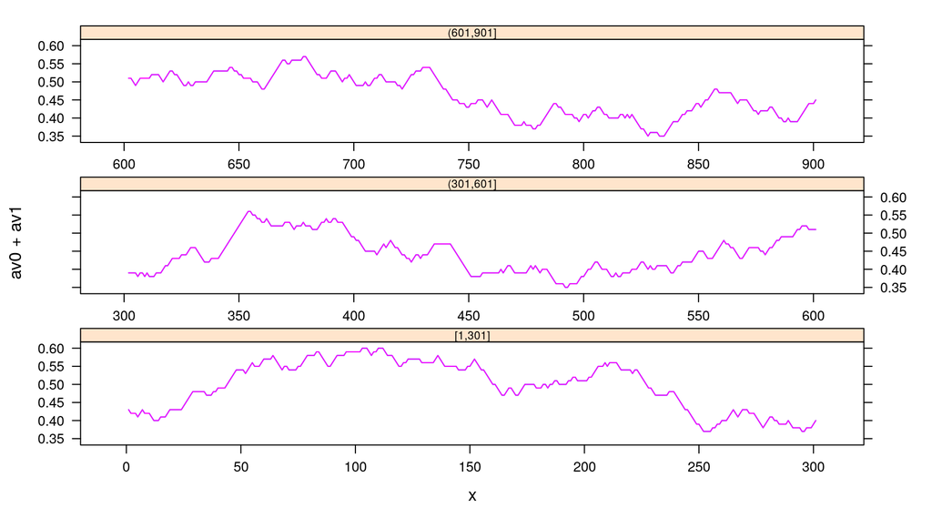

```r
plotmarkov <-
  function(n=1000, start=1, window=100, transition=transitionMatrix, npanels=3){
    xc2 <- Markov(n, start, transition)
    mav0 <- rollmean(as.integer(xc2==0), window) #mav0 and mav1 are equal
    mav1 <- rollmean(as.integer(xc2==0), window) #why having two moving averages that are equal ??
    print( Reduce("&&", mav0 == mav1) )
    npanel <- cut(1:length(mav0), breaks=seq(from=1, to=length(mav0),
                  length=npanels+1), include.lowest=TRUE)
    df <- data.frame(av0=mav0, av1=mav1, x=1:length(mav0),
                     gp=npanel)
    print(xyplot(av0+av1 ~ x | gp, data=df, layout=c(1,npanels),
          type="l", par.strip.text=list(cex=0.65),
          scales=list(x=list(relation="free"))))
  }

set.seed(50)
plotmarkov()
```

```
## [1] TRUE
```

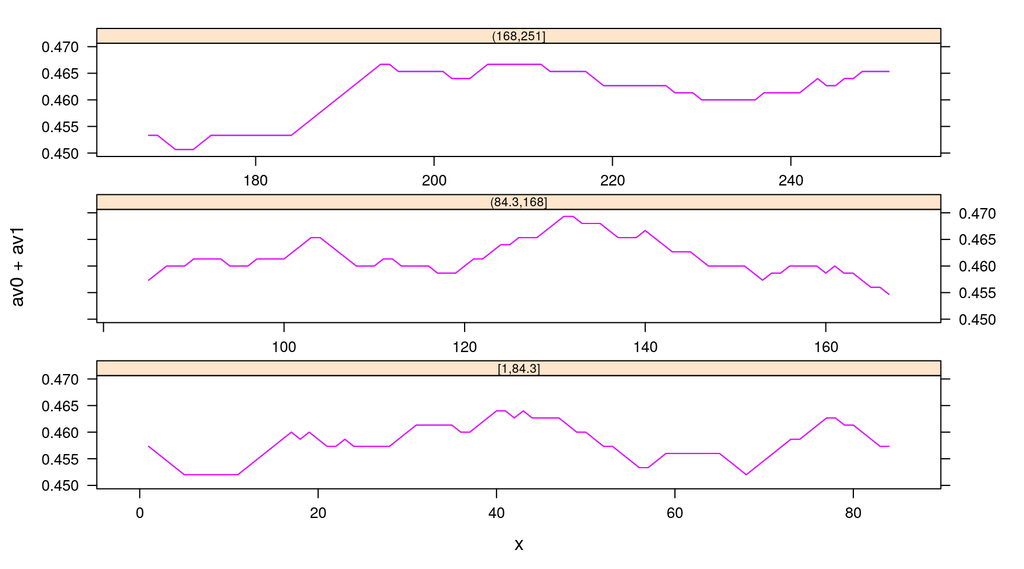

```r
plotmarkov(window = 750)
```

```
## [1] TRUE
```

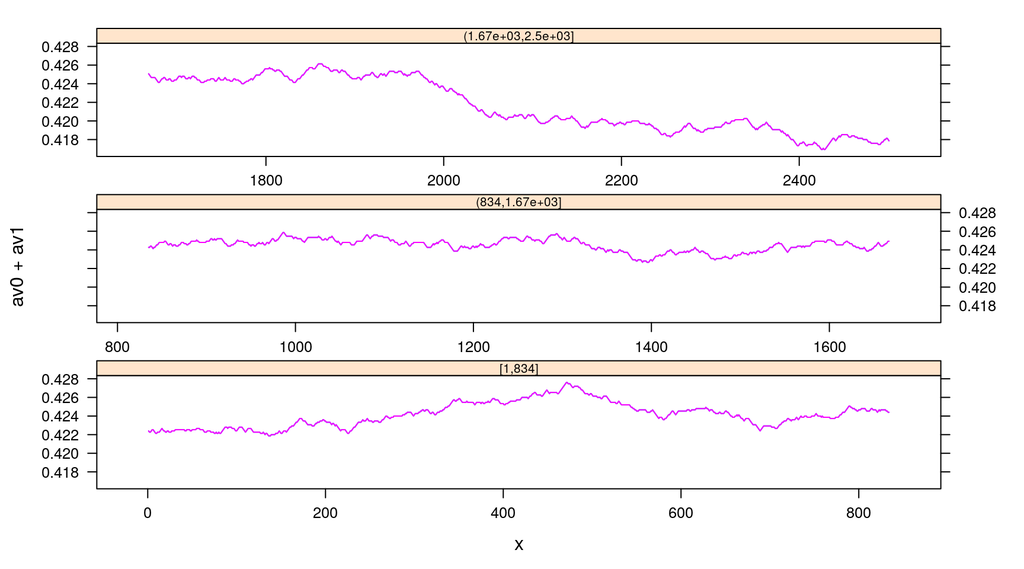

```r
plotmarkov(10000, window = 7500)
```

```
## [1] TRUE
```

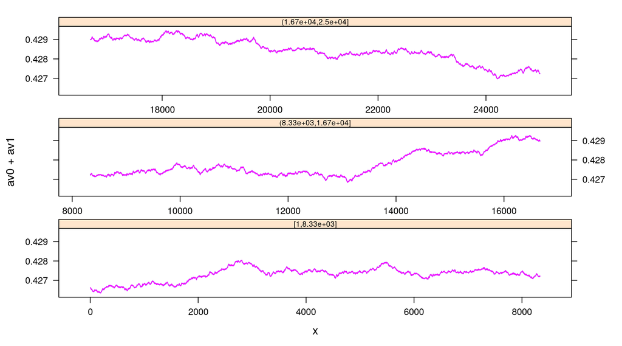

```r
plotmarkov(100000, window = 75000)
```

```
## [1] TRUE
```

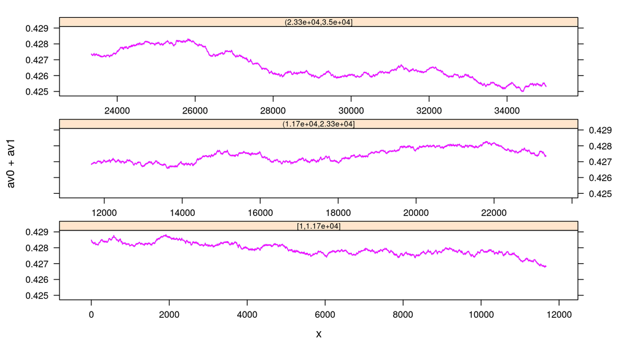

```r
plotmarkov(110000, window = 75000)
```

```
## [1] TRUE
```

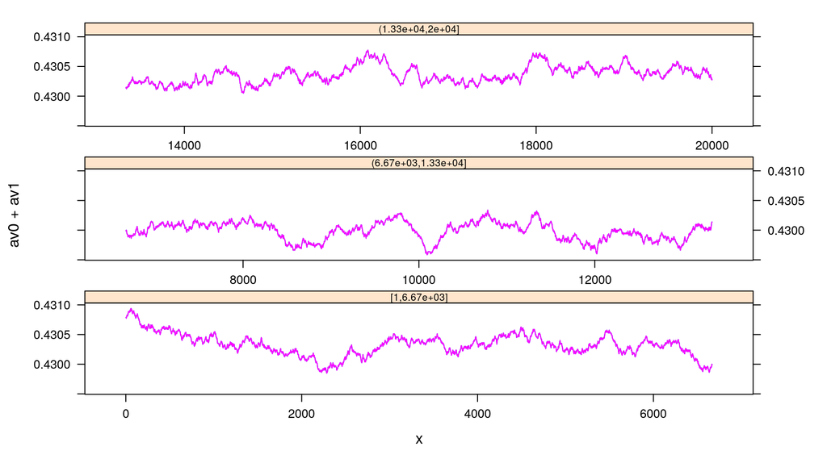

```r
plotmarkov(100000, window = 80000)
```

```
## [1] TRUE
```

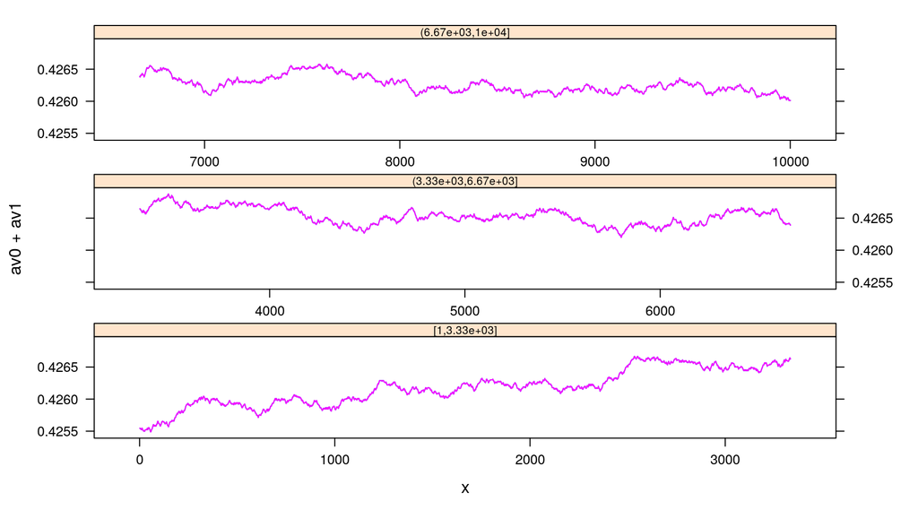

```r
plotmarkov(100000, window = 90000)
```

```
## [1] TRUE
```

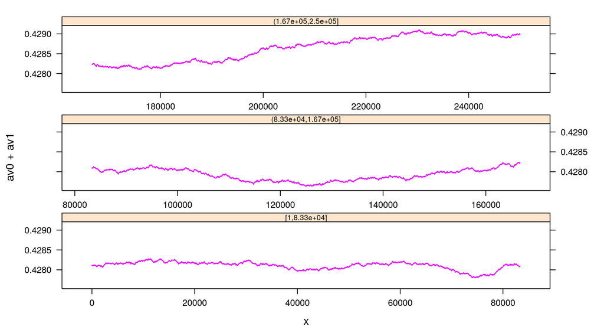

```r
plotmarkov(1000000, window = 750000)
```

**Try varying the number of simulations and the width of the window. How wide a window is needed to get a good sense of the stationary distribution? This series settles down rather quickly to its stationary distribution (it “burns in” quite quickly). A reasonable width of window is, however, needed to give an accurate indication of the stationary distribution.**

The window size must cover most part of the sample size (i.e. 75%). It is possible to observe the 4-th and the last plot, respectively generated by `plotmarkov(100000, window = 75000)` and `plotmarkov(1000000, window = 750000)` shows clearly how the rolling mean is stable around $0.429$.

## Exercise 6 cap 4

**Here we generate random normal numbers with a sequential dependence structure:**

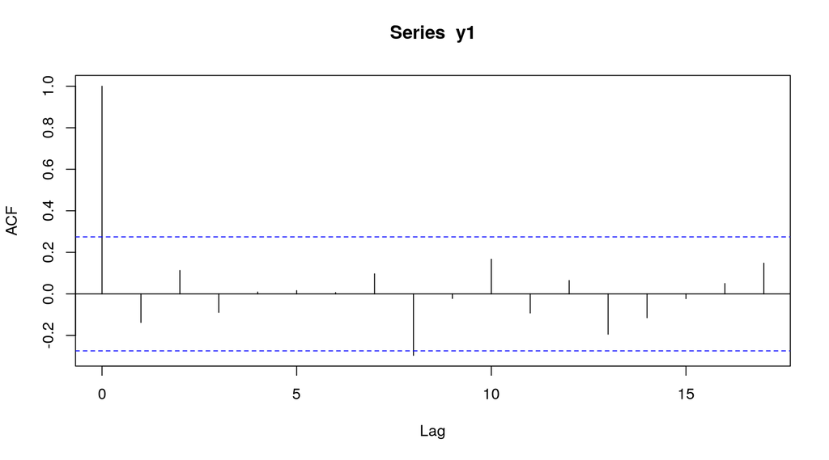

```r
y1 <- rnorm(51)
y <- y1[-1] + y1[-51]
acf(y1)
```

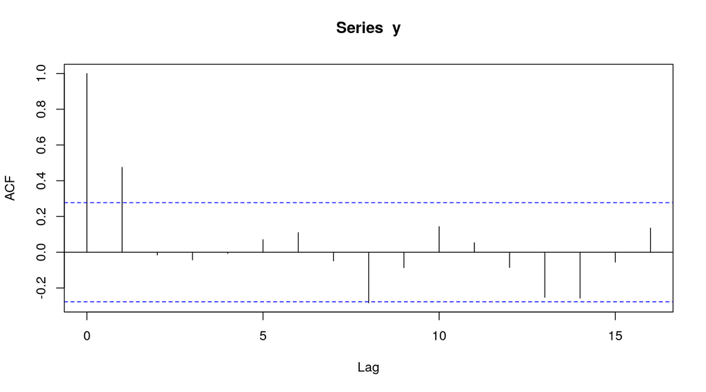

```r
# acf is ‘autocorrelation function’
# (see Chapter 9)
acf(y)
```

**Repeat this several times. There should be no consistent pattern in the acf plot for different random samples `y1`. There will be a fairly consistent pattern in the `acf` plot for `y`, a result of the correlation that is introduced by adding to each value the next value in the sequence.**

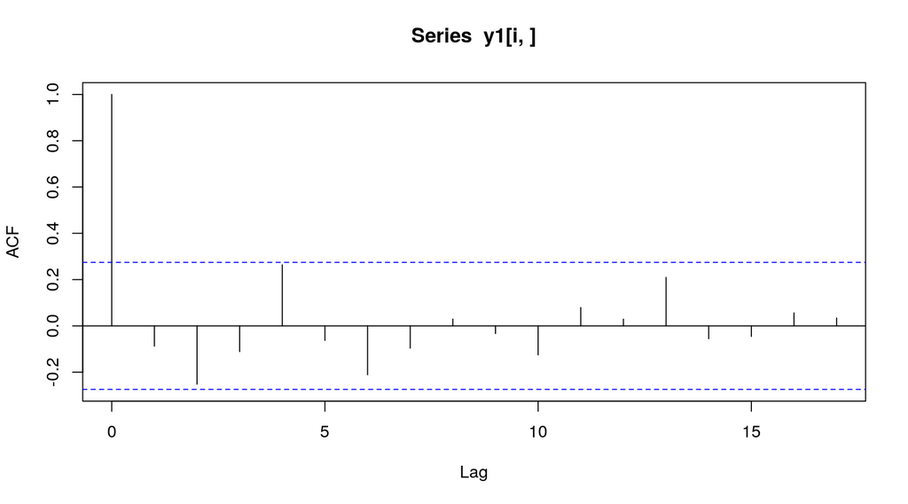

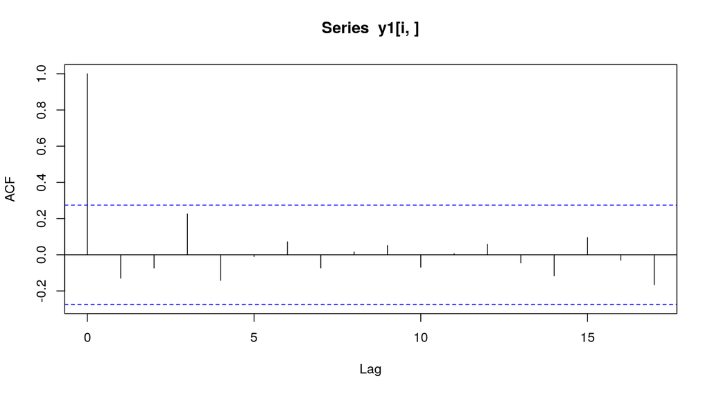

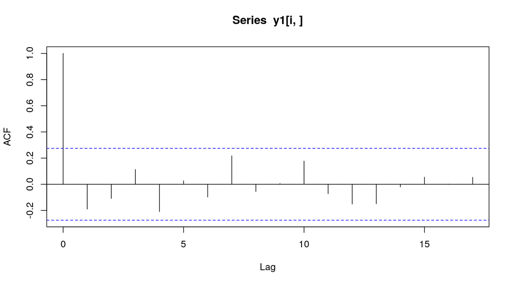

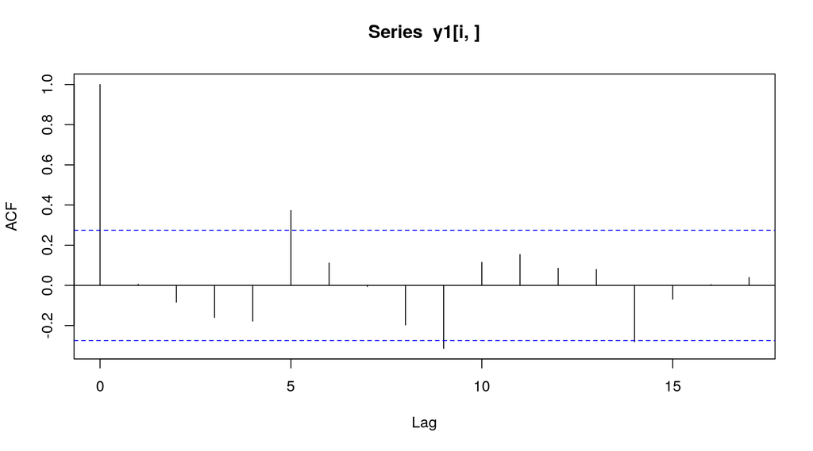

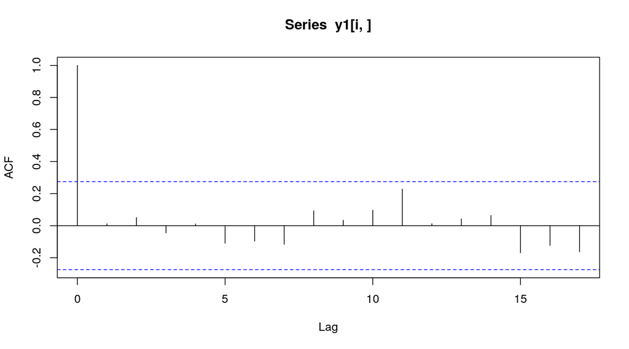

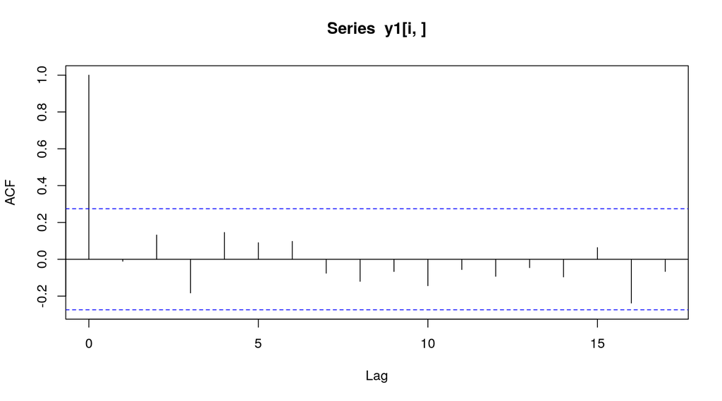

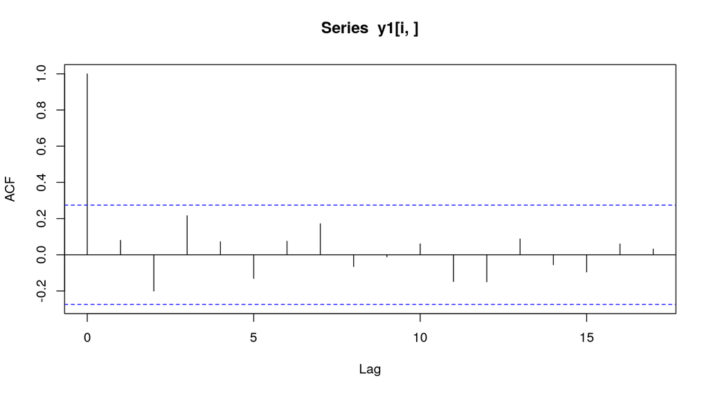

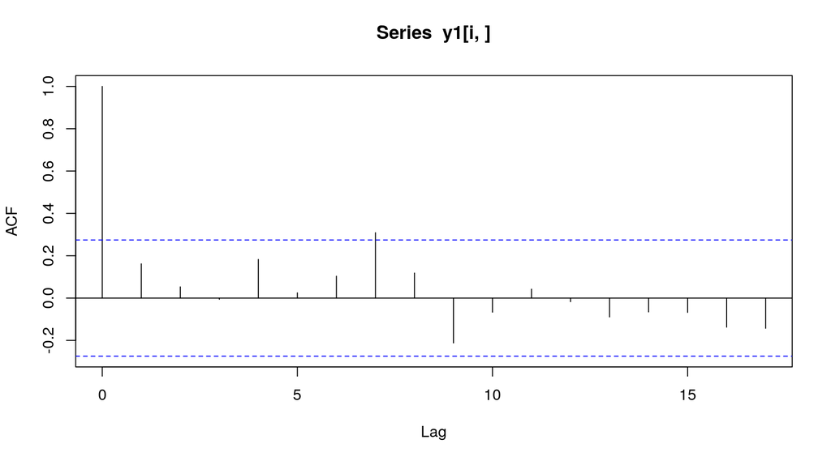

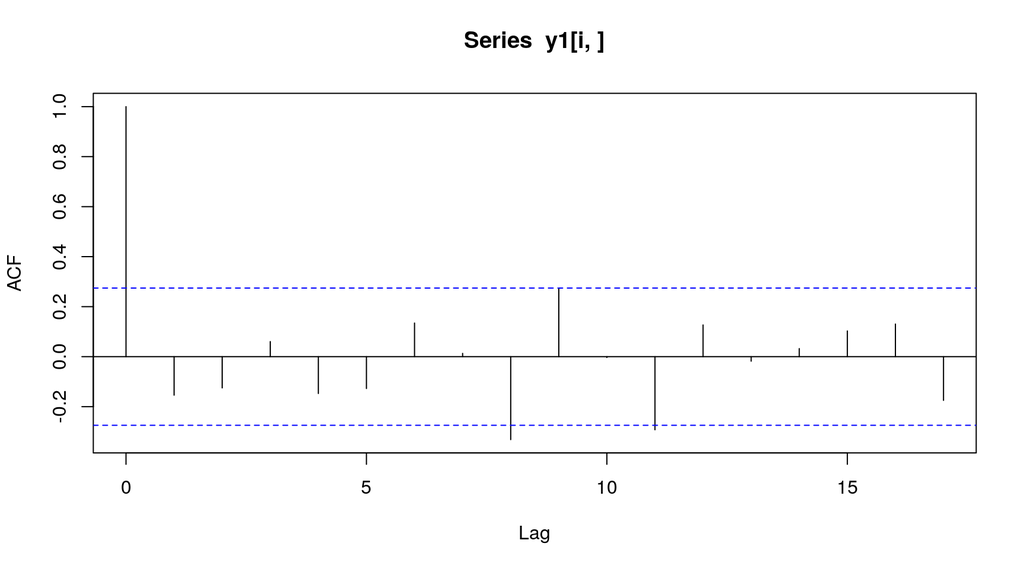

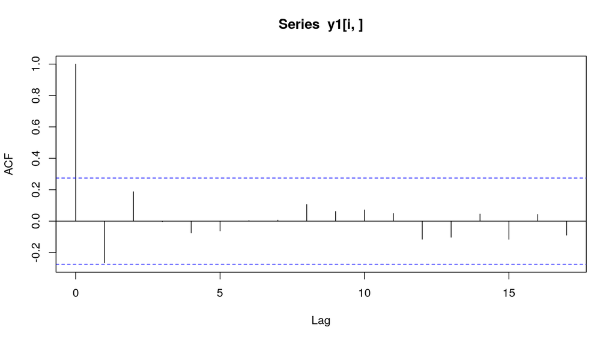

```r
#set the number of times the procedure is repeated
n <- 10
#matrices to store the data
y1 <- array(0, c(n,51))
y <- array(0,c(n,50))

#generation of y1 and y values
for (i in 1:n) {
  y1[i ,] <- rnorm(51)
  y[i ,] <- y1[i,-1] + y1[i,-51]
}

#plots
for (i in 1:n) {
  acf(y1[i, ])
}
```